# analysis project 2

```r
mydata1 <- mydata1 %>%
  mutate(PropertyCategory_clean = tolower(PropertyCategory_clean))
```

```r
unique(mydata1$PropertyCategory_clean)
```

```
## [1] "dwelling"          "outdoor structure" "non residential"
## [4] "outdoor"           "road vehicle"      "other residential"
## [7] "boat"
```

Visualize the property category table, check which property has what frequency count, we can train more staff to handle calls on this type of property category.

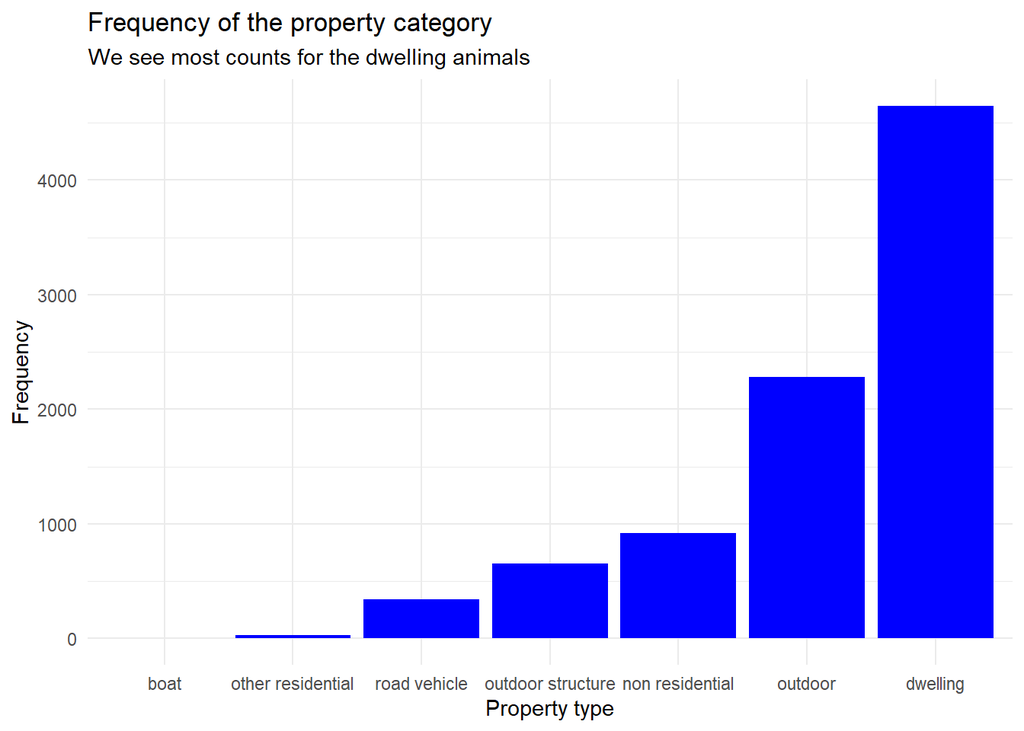

```r
mydata1 %>%
  group_by(PropertyCategory_clean) %>%
  summarize(frequency = n()) %>%
  mutate(PropertyCategory_clean = fct_reorder(PropertyCategory_clean, frequency)) %>%
  ggplot(aes(x = PropertyCategory_clean, y = frequency)) +
  geom_bar(stat = "identity", fill = "blue") +
  theme_minimal() +
  xlab("Property type") + ylab("Frequency") + scale_fill_brewer(palette = "Paired") +
  labs(title = "Frequency of the property category",
       subtitle= "We see most counts for the dwelling animals")+ guides(fill = "none")
```

Next we want to see the average national cost for each property category

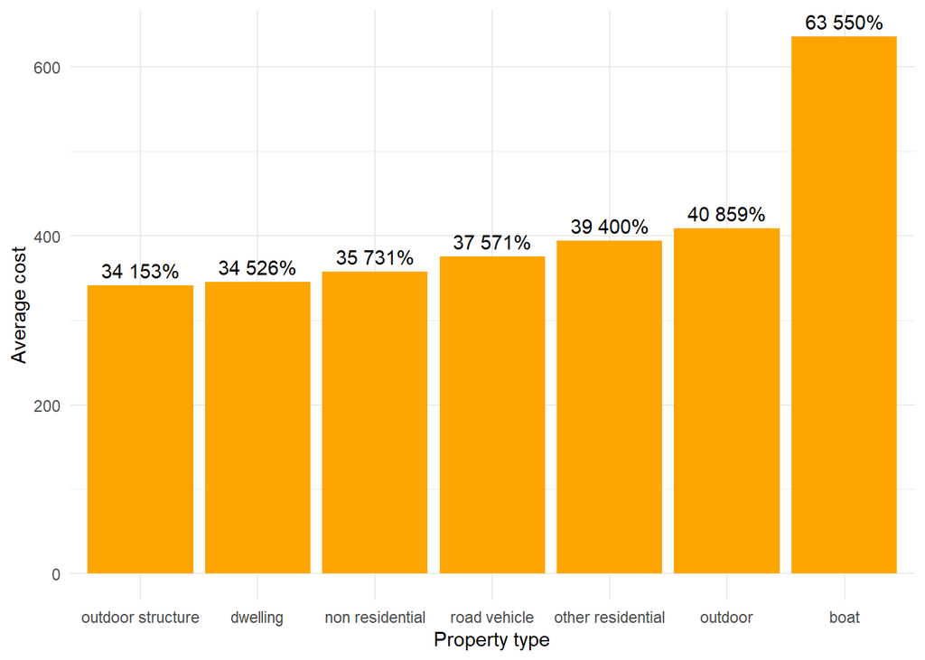

```r
mydata1 %>%
  group_by(PropertyCategory_clean) %>%
  summarize(avg_cost = mean(IncidentNationalCost)) %>%
  mutate(PropertyCategory_clean = fct_reorder(PropertyCategory_clean, avg_cost )) %>%
  ggplot(aes(x = PropertyCategory_clean, y = avg_cost)) +
  geom_bar(stat = "identity", fill = "orange") +
  geom_text(aes(label = scales::percent(avg_cost), y = avg_cost), stat = "identity", vjust = -0.5) +
  theme_minimal() +
  xlab("Property type") + ylab("Average cost")
```

The cost of rescuing an animal from a boat incident is more expensive as expected, due to the extra expertise the worker may need to maneuver, the Property type with more frequency is the Dwelling, so we may have to focus more resources there.

Now we check the Animal group parent column to confirm what animals have the most count and cost

```r
unique(mydata1$AnimalGroupParent)
```

```
##  [1] "Dog"
##  [2] "Fox"
##  [3] "Horse"
##  [4] "Ra^&it"
##  [5] "Unknown - Heavy Livestock Animal"
##  [6] "Squirrel"
##  [7] "Cat"
##  [8] "Bird"
##  [9] "D+g"
## [10] "Unknown - Domestic Animal Or Pet"
## [11] "Ca&"
## [12] "Sheep"
## [13] "Ca$"
## [14] "Bir*"
## [15] "Deer"
```

[output cut: 19 more lines]

clean the Animal group parent column

```r
mydata1$AnimalGroupParent_clean <- ifelse(mydata1$AnimalGroupParent == "Ra^&it","Rabbit",
                                   ifelse(mydata1$AnimalGroupParent =="D+g", "Dog",
                                          ifelse(mydata1$AnimalGroupParent == "Ca&", "Cat",
                                                 ifelse(mydata1$AnimalGroupParent == "Ca$", "Cat",
                                                        ifelse(mydata1$AnimalGroupParent == "Bir*", "Bird",
                                                               ifelse(mydata1$AnimalGroupParent == "Bi^&", "Bird", mydata1$AnimalGroupParent))))))
```

```r
mydata1 <- mydata1 %>%
  mutate(AnimalGroupParent_clean = tolower(AnimalGroupParent_clean))
```

```r
unique(mydata1$AnimalGroupParent_clean)
```

```
##  [1] "dog"
##  [2] "fox"
##  [3] "horse"
##  [4] "rabbit"
##  [5] "unknown - heavy livestock animal"
##  [6] "squirrel"
##  [7] "cat"
##  [8] "bird"
##  [9] "unknown - domestic animal or pet"
## [10] "sheep"
## [11] "deer"
## [12] "unknown - wild animal"
## [13] "snake"
## [14] "lizard"
## [15] "hedgehog"
## [16] "hamster"
## [17] "lamb"
## [18] "fish"
## [19] "bull"
## [20] "cow"
## [21] "ferret"
## [22] "budgie"
## [23] "unknown - animal rescue from water - farm animal"
## [24] "pigeon"
## [25] "goat"
## [26] "tortoise"
## [27] "unknown - animal rescue from below ground - farm animal"
```

Lets see the frequency of these values

```r
AnimalGroupParent_freq <- table(mydata1$AnimalGroupParent_clean)
```

```r
c(max = round(max(AnimalGroupParent_freq)), avg = round(mean(AnimalGroupParent_freq)), min = round(min(AnimalGroupParent_freq)))
```

```
##  max  avg  min
## 4342  329    1
```

```r
view(sort(table(mydata1$AnimalGroupParent_clean), decreasing = TRUE))
```

```r
mydata1$short_label <- str_sub(mydata1$AnimalGroupParent_clean,1,10)
```

We make a plot of the frequency of Animal group, and further group these by the Property category.

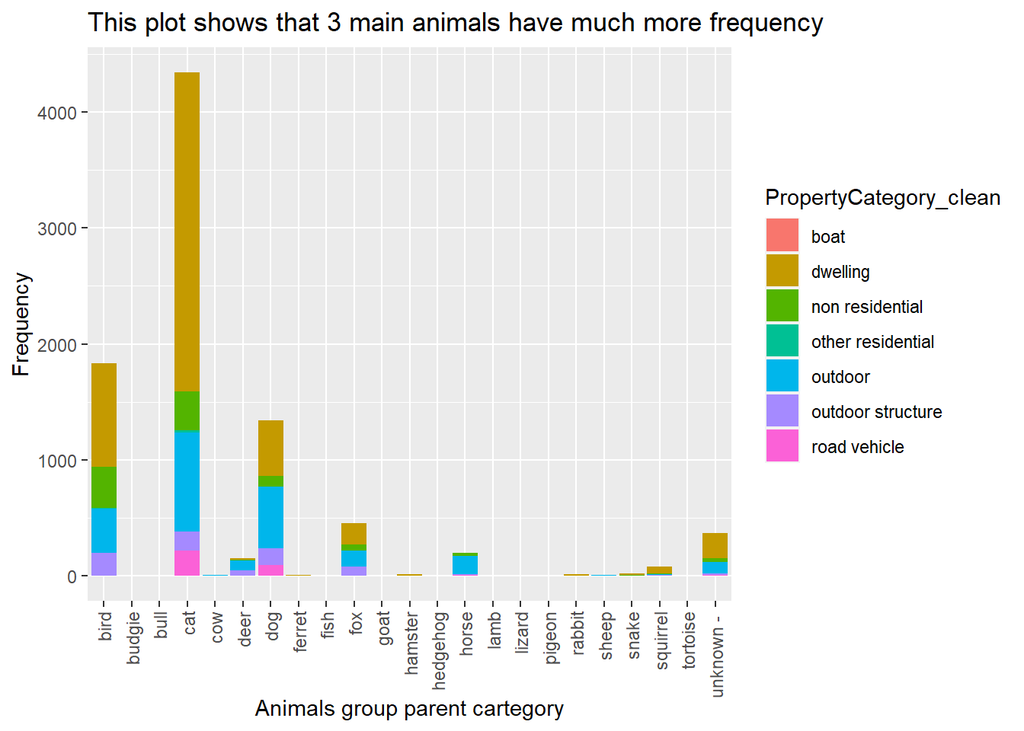

```r
ggplot(mydata1, aes(x = short_label, fill = PropertyCategory_clean)) +
  geom_bar(stat = "count") +
  xlab("Animals group parent cartegory") +
  ylab("Frequency") +
  ggtitle("This plot shows that 3 main animals have much more frequency")+
  theme(axis.text.x = element_text(angle = 90, vjust = 0.5, hjust = 1))
```

We create a plot to see the incident cost distribution for the various animal category

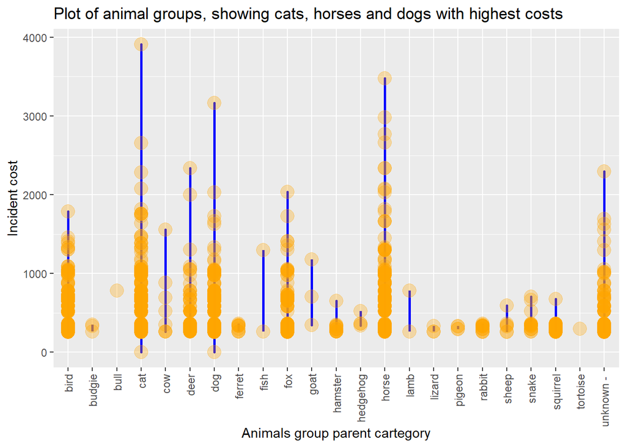

```r
ggplot(mydata1, aes(x = short_label, y = IncidentNationalCost)) +
  geom_line(size = 1, color = "blue") +
  geom_point(color = "orange", size = 5,  alpha = 0.3 ) +
  xlab("Animals group parent cartegory") +
  ylab("Incident cost") + guides (fill = "none") +
  ggtitle("Plot of animal groups, showing cats, horses and dogs with highest costs")+
  theme(axis.text.x = element_text(angle = 90, vjust = 0.5, hjust = 1))
```

The obvious animal groups are the bird, cat and the dog. we shall filter for these animals for a later analysis. cats get the highest frequency of calls and is amog the most expensive to rescue

Now we check the area column

```r
unique(mydata$Area)
```

```
##  [1] "Ranelagh"      "Sutton"        "Smithfield"    "Perrystown"
##  [5] "Crumlin"       "Milltown"      "Belfield"      "Rathfarnham"
##  [9] "Terenure"      "Rathmines"     "Templeogue"    "Dundrum"
## [13] "Walkinstown"   "Leopardstown"  "Stepaside"     "Tallaght"
## [17] "Clontarf"      "Harolds Cross" "Donnybrook"    "Killester"
## [21] "Ballymun"      "Ballyfermot"   "Drumcondra"    "Clonsilla"
## [25] "Dalkey"        "Cabra"         "Glasnevin"     "Santry"
## [29] "Portobello"    "Killiney"      "Blackrock"     "Dun laoighre"
## [33] "Temple Bar"    "Rathm&^es"     "Drumco\"!ra"   "Ta!!aght"
## [37] "Donnybr$*k"    "Clondalkin"    "Finglas"       "Castleknock"
## [41] "Tandridge"     "SUTTON"        ""
```

clean the Area column

```r
mydata1$Area_clean <- ifelse(mydata1$Area == "Ta!!aght", "Tallaght",
                      ifelse(mydata1$Area =="Donnybr$*k", "Donnybrook",
                             ifelse(mydata1$Area == "Rathm&^es","Rathmines",
                                    ifelse(mydata1$Area == "Drumco\"!ra","Drumcondra",
                                           ifelse(mydata1$Area == "", "Unknown", mydata1$Area)))))
```

```r
mydata1 <- mydata1 %>%
  mutate(Area_clean = tolower(Area_clean))
```

```r
unique(mydata1$Area_clean)
```

```
##  [1] "ranelagh"      "sutton"        "smithfield"    "perrystown"
##  [5] "crumlin"       "milltown"      "belfield"      "rathfarnham"
##  [9] "terenure"      "rathmines"     "templeogue"    "dundrum"
## [13] "walkinstown"   "leopardstown"  "stepaside"     "tallaght"
## [17] "clontarf"      "harolds cross" "donnybrook"    "killester"
## [21] "ballymun"      "ballyfermot"   "drumcondra"    "clonsilla"
## [25] "dalkey"        "cabra"         "glasnevin"     "santry"
## [29] "portobello"    "killiney"      "blackrock"     "dun laoighre"
## [33] "temple bar"    "clondalkin"    "finglas"       "castleknock"
## [37] "tandridge"     "unknown"
```

We explore the Area column further

```r
view(sort(table(mydata1$Area_clean), decreasing = TRUE))
```

```r
Area_freq <- table(mydata1$Area_clean)
```

```r
c(max = round(max(Area_freq)), avg = round(mean(Area_freq)), min = round(min(Area_freq)))
```

```
## max avg min
## 395 234   1
```

We create a lollipop plot to broadly view the average incident costs for the areas in our column

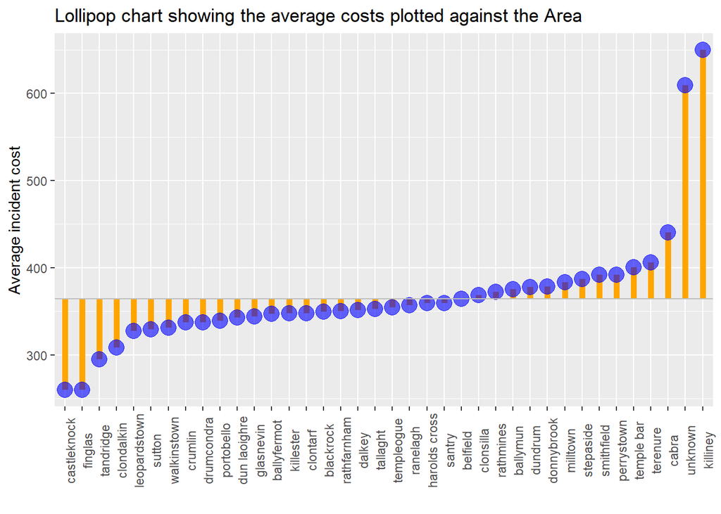

```r
mydata1 %>%
  group_by(Area_clean) %>%
  summarize(avg_cost = mean(IncidentNationalCost)) %>%
  mutate(Area_clean = fct_reorder(Area_clean, avg_cost)) %>%
  ggplot(aes(x = Area_clean, y = avg_cost)) +
  geom_segment(aes(x = Area_clean, xend = Area_clean, y = mean(mydata1$IncidentNationalCost), yend = avg_cost), color = "Orange", size = 2) +
  geom_point(size = 5, color = "blue", alpha = 0.6) +
  geom_hline(yintercept = mean(mydata1$IncidentNationalCost), color = "grey", linetype = "solid") + theme(axis.text.x = element_text(angle = 90)) +
  xlab("") +
  ylab("Average incident cost")+
   labs(title = "Lollipop chart showing the average costs plotted against the Area")
```

Creating a frequency plot to see the Area column

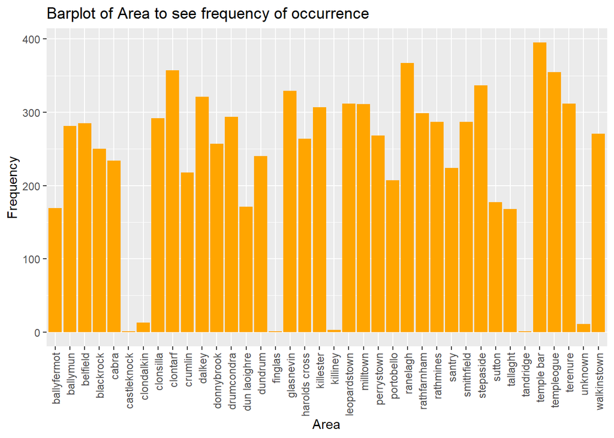

```r
ggplot(mydata1, aes(x = Area_clean, fill = "mean_cost")) +
  geom_bar(stat = "count", fill = "orange") +
  theme(axis.text.x = element_text(angle = 90, vjust = 0.5, hjust=1)) +
  xlab("Area") +
  ylab("Frequency") +
  ggtitle("Barplot of Area to see frequency of occurrence")
```

lets check the top 3 incident call areas

```r
Area_freq <- table(mydata1$Area_clean)
```

```r
view(top_Areas <- names(sort(Area_freq, decreasing = TRUE))[1:3])
```

```r
top_Areas_filtered <- subset(mydata1, Area_clean %in% top_Areas)
```

We identify a particular Area, Sutton and make a visualization to view the Animals and costs, faceted by the Property types they are rescued from

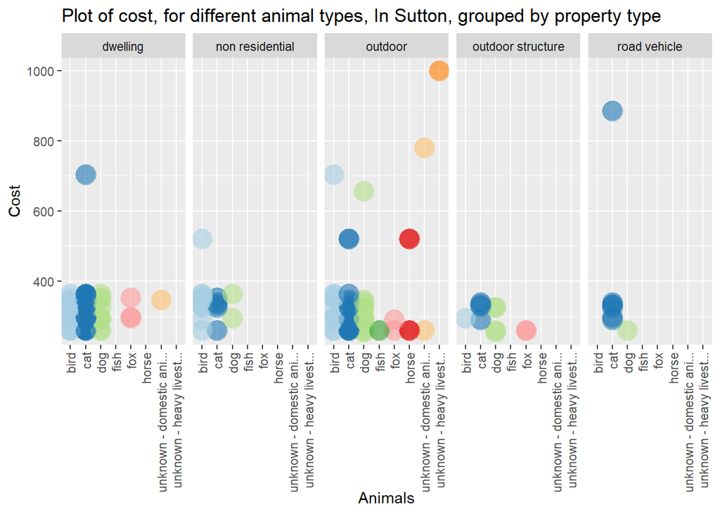

```r
mydata1 %>%
  filter(Area_clean == "sutton") %>%
  ggplot(aes(x = str_trunc(AnimalGroupParent_clean, 25), y = IncidentNationalCost, group = PropertyCategory_clean, color = AnimalGroupParent_clean, size = 2)) +
  geom_point(alpha = 0.6) +
  xlab("Animals") +
  ylab("Cost") +
  ggtitle("Plot of cost, for different animal types, In Sutton, grouped by property type") +
  theme(axis.text.x = element_text(angle = 90, vjust = 0.5, hjust = 1))+
  facet_grid(~ PropertyCategory_clean)+
  scale_color_brewer(palette = "Paired") +
  scale_size(range = c(3, 8)) +
  guides(color = "none", size = "none")
```

We can repeat the above code for any particular area of interest, so as to understand where we need to allocate more resources

Now we clean and explore the trends shown by our date column

```r
typeof(mydata1$DateTimeOfCall)
```

```
## [1] "character"
```

```r
str(mydata1$DateTimeOfCall)
```

```
##  chr [1:8876] "01/01/2009 03:01" "01/01/2009 08:51" "04/01/2009 10:07" ...
```

```r
mydata1$date <- dmy_hm(mydata1$DateTimeOfCall)
```

Create a weekday column

```r
mydata1$wday <- weekdays(mydata1$date)
```

Filter the data to only include the values “cat”, “dog”, and “bird”

```r
filtered_data <- mydata1 %>% filter(AnimalGroupParent_clean %in% c("cat", "dog", "bird"))
```

Now Calculate the mean cost for each day of the week

```r
mean_cost_by_day_and_animal <- filtered_data %>%
  group_by(wday, AnimalGroupParent_clean, SpecialServiceTypeCategory) %>%
  summarise(mean_cost = mean(IncidentNationalCost))
```

Create the plot for dog, cat, and bird, identifying mean costs and grouping by week days

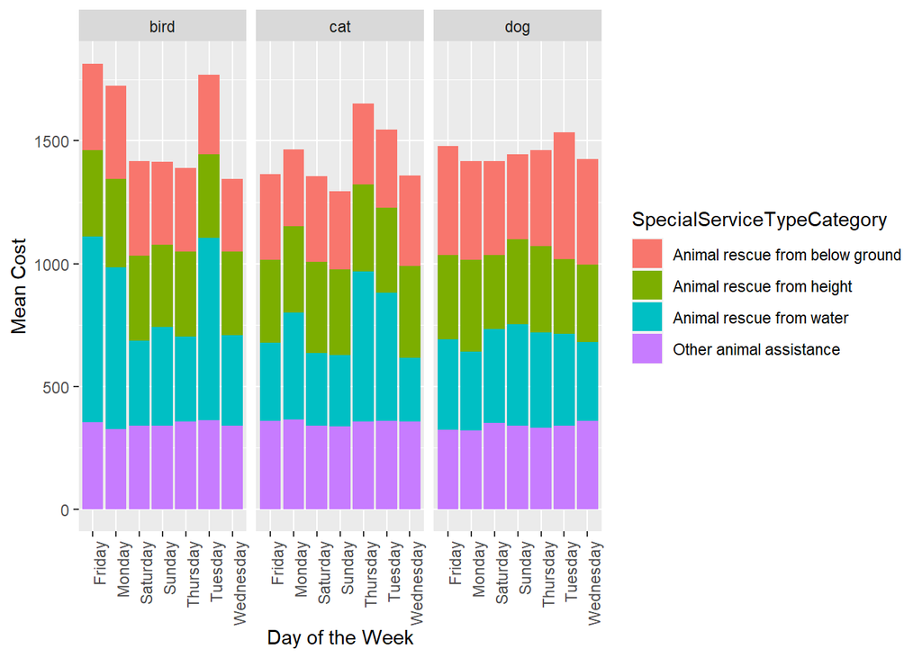

```r
ggplot(mean_cost_by_day_and_animal, aes(x = wday, y = mean_cost, fill = SpecialServiceTypeCategory)) +
  geom_bar(stat = "identity") +
  theme(axis.text.x = element_text(angle = 90, hjust = 1)) +
  facet_wrap(~ AnimalGroupParent_clean) +
  ylab("Mean Cost") +
  xlab("Day of the Week") +
  scale_fill_discrete(name = "SpecialServiceTypeCategory")
```

Now we create a new column called months of the year

```r
mydata1$month <- month(mydata1$date, label = TRUE)
```

We group our columns of interest

```r
mean_values <- mydata1 %>%
  group_by(month, SpecialServiceTypeCategory) %>%
  summarise(SpecialServiceTypeCategory, IncidentNationalCost, PropertyCategory_clean)
```

[output not shown]

Now we make a plot to see the costs per month grouped into Property category

[figure not shown]

```r
ggplot(mean_values, aes(x = month, y = IncidentNationalCost, color = PropertyCategory_clean)) +
  geom_line(size = 4) +
  ylab("Mean Cost") +
  xlab("Month")+
  guides(color = guide_legend(title = "Property"))+
  ggtitle("Average cost per month, grouped by property type")
```

Now we further group the plot by separating it into service category

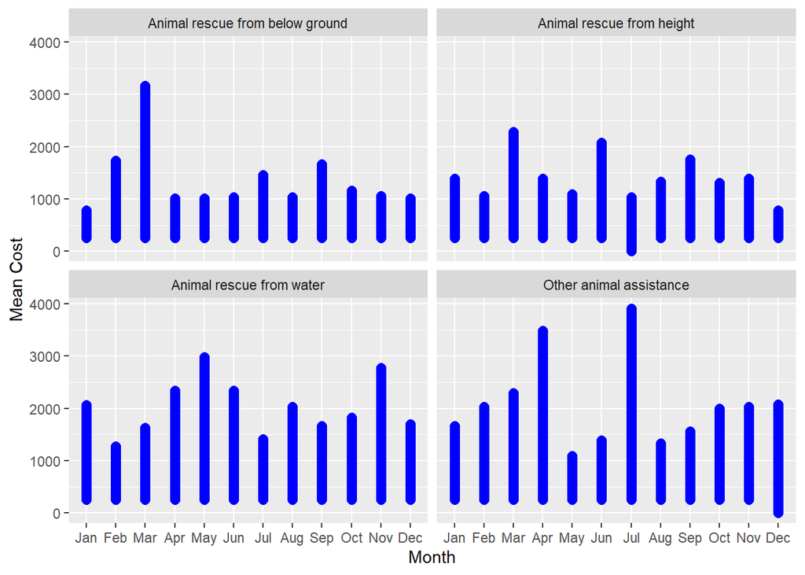

```r
ggplot(mean_values, aes(x = month, y = IncidentNationalCost)) +
  geom_line(size = 3, color = "blue") +
  ylab("Mean Cost") +
  xlab("Month") +
  facet_wrap(~ SpecialServiceTypeCategory)
```

We highlight the “Other Animal assistance column and explore the top animals therein

```r
filtered_data3 <- mydata1 %>% filter(SpecialServiceTypeCategory %in% c("Other animal assistance"))%>%
  filter(AnimalGroupParent_clean %in% c("dog", "cat", "bird"))
```

```r
mean_cost_other_animals <- filtered_data3 %>%
  group_by(AnimalGroupParent_clean) %>%
  summarise(AnimalGroupParent_clean, IncidentNationalCost, PropertyCategory_clean)
```

We create a plot for this particular column to see the costs per animal in dog, cat and bird.

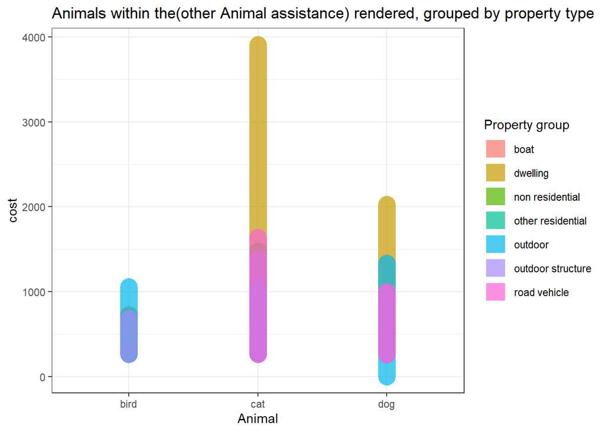

```r
ggplot(mean_cost_other_animals, aes(x = AnimalGroupParent_clean, y = IncidentNationalCost,
                                    color = PropertyCategory_clean))+
  geom_line(size = 7, alpha = 0.7) +
  ylab("cost") +
  xlab("Animal")+
  guides(color = guide_legend(title = "Property group"))+
  theme_bw()+
  ggtitle("Animals within the(other Animal assistance) rendered, grouped by property type")
```

```r
colnames(mydata1)
```

```
##  [1] "DateTimeOfCall"             "HourlyNationalCost"
##  [3] "IncidentNationalCost"       "AnimalGroupParent"
##  [5] "PropertyCategory"           "SpecialServiceTypeCategory"
##  [7] "SpecialServiceType"         "Area"
##  [9] "PropertyCategory_clean"     "AnimalGroupParent_clean"
## [11] "short_label"                "Area_clean"
## [13] "date"                       "wday"
## [15] "month"
```